# Compositional Analysis

# Clustering Surface Communites (Figure 1D)

```r
# First, May
surf_may <- full_abs_physeq %>%
  ps_filter(month=="May", Depth_Class == "E")

# Identify May Samples
keeps <- sample_names(surf_may)

# Filter our distance matrix just for Surface May samples
temp_mat <- as.matrix(abs_unifrac_dist_0.5)

all(colnames(temp_mat) == rownames(temp_mat))
```

```
## [1] TRUE
```

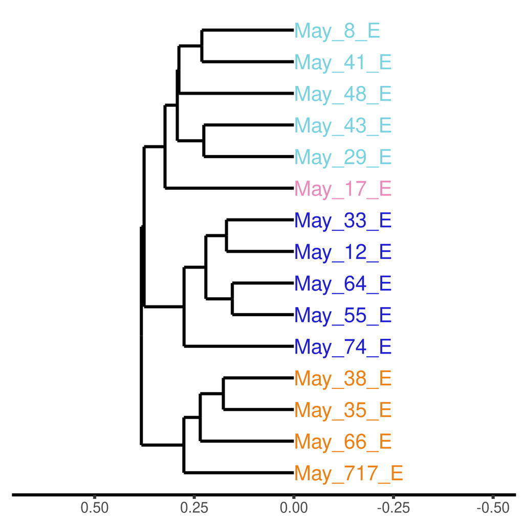

```r
keep_i <- colnames(temp_mat) %in% keeps

surf_may_dist <- as.dist(temp_mat[keep_i, keep_i])

# Cluster
surf_may_hclust <- surf_may_dist %>%
  hclust(method = "average")

# Define a height at which to cut the tree
height = 0.32

may_surf_groups <- cutree(surf_may_hclust, k = 4)

# Plot our dendrogram
may_surf_d <- as.dendrogram(surf_may_hclust)

data <- dendro_data(may_surf_d)

may_clust_df <- data.frame(cluster = factor(may_surf_groups[match(data$labels$label,names(may_surf_groups))]),
                           Rep_ID = data$labels$label)

ggplot(segment(data)) +
  geom_segment(aes(x = x, y = y, xend = xend, yend = yend),
               linewidth = 1) +
  coord_flip() +
  geom_text(data = may_clust_df, aes(label = Rep_ID, color = cluster, y = 0, x = c(1:15)), size = 5, hjust = 0) +
  scale_y_reverse(limits = c(.65, -.5)) +
  theme(axis.title.y  = element_blank(),
        axis.line.y = element_blank(),
        axis.ticks.y = element_blank(),
        axis.text.y = element_blank(),
        axis.title.x = element_blank(),
        axis.text.x = element_text(size = 10),
        axis.line.x = element_line(linewidth  = 1),
        axis.ticks.x = element_line(linewidth = 1),
        legend.position = "none") +
  scale_color_manual(values = c("#211ed2","#ea8bb9","#79d3df","#ed8114"))
```

```r
surf_sep <- full_abs_physeq %>%
  ps_filter(month=="September", Depth_Class == "E")

keeps <- sample_names(surf_sep)

temp_mat <- as.matrix(abs_unifrac_dist_0.5)

all(colnames(temp_mat) == rownames(temp_mat))
```

```
## [1] TRUE
```

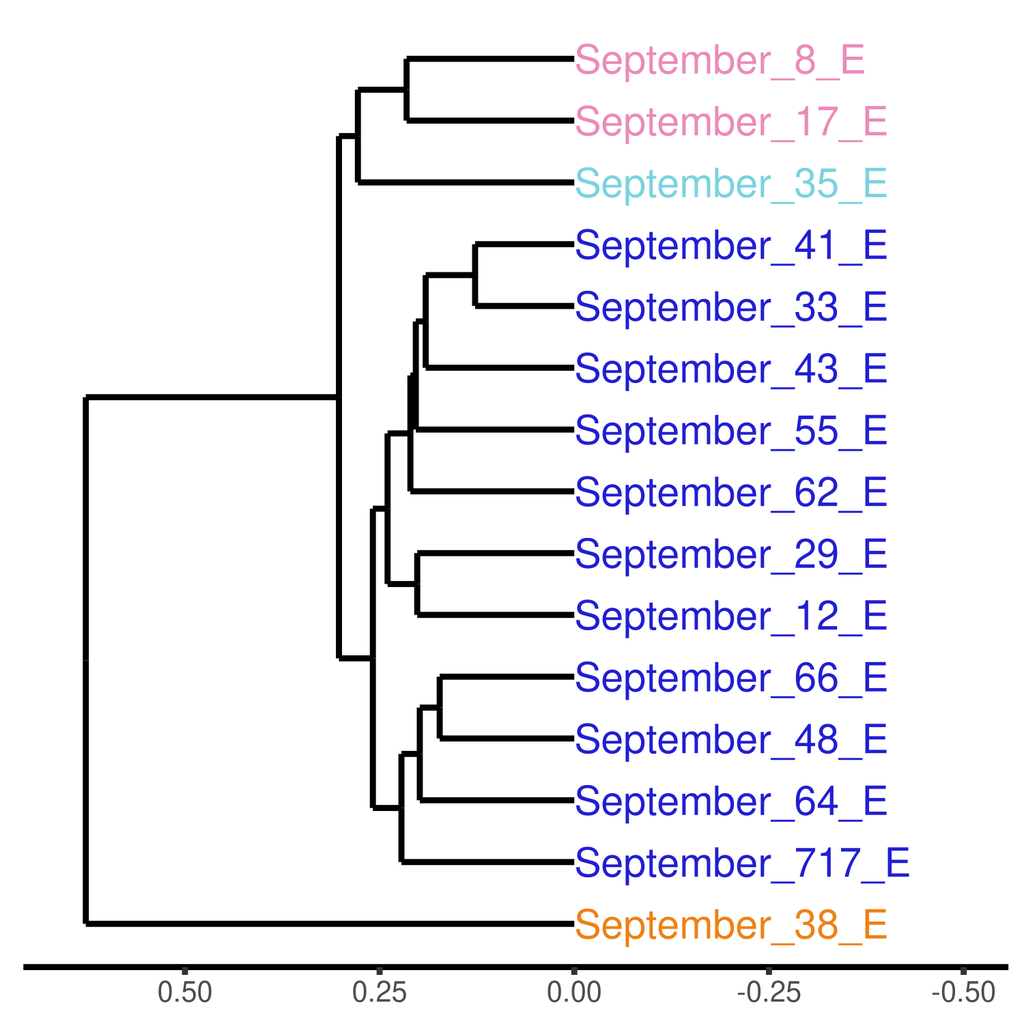

```r
keep_i <- colnames(temp_mat) %in% keeps

surf_sep_dist <- as.dist(temp_mat[keep_i, keep_i])

surf_sep_hclust <- surf_sep_dist %>%
  hclust(method = "average")

sep_surf_groups <- cutree(surf_sep_hclust, k = 4)

sep_surf_d <- as.dendrogram(surf_sep_hclust)

data <- dendro_data(sep_surf_d)

sep_clust_df <- data.frame(cluster = factor(sep_surf_groups[match(data$labels$label,names(sep_surf_groups))]),
                           Rep_ID = data$labels$label)

ggplot(segment(data)) +
  geom_segment(aes(x = x, y = y, xend = xend, yend = yend),
               linewidth = 1) +
  coord_flip() +
  geom_text(data = sep_clust_df, aes(label = Rep_ID, color = cluster, y = 0, x = c(1:15)), size = 5, hjust = 0) +
  scale_y_reverse(limits = c(.65, -.5)) +
  theme(axis.title.y  = element_blank(),
        axis.line.y = element_blank(),
        axis.ticks.y = element_blank(),
        axis.text.y = element_blank(),
        axis.title.x = element_blank(),
        axis.text.x = element_text(size = 10),
        axis.line.x = element_line(linewidth = 1),
        axis.ticks.x = element_line(linewidth = 1),
        legend.position = "none") +
  scale_color_manual(values = c("#211ed2","#ea8bb9","#79d3df","#ed8114"))
```

# PCA of Environmental Metadata

How do our stations cluster based on metadata? Below, I select numerical metadata from each station and use a PCA to plot stations based on their environmental characteristics.

It took a lot of work to make the PCA and PCoA look the same, haha, but I think it was worth it.

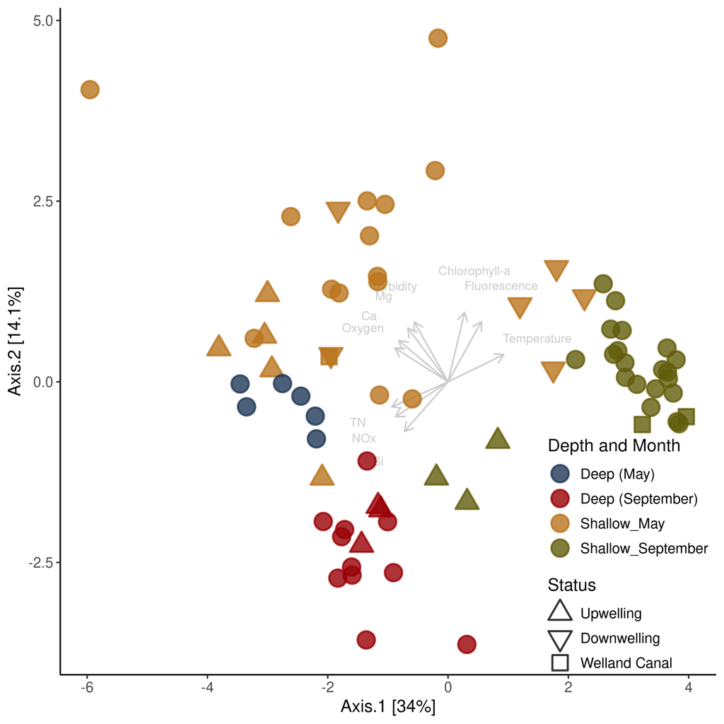

```r
# Select our environmental metadata
metadata_df <- full_abs_physeq %>%
  sample_data() %>%
  data.frame() %>%
  select(good_oxygen, upoly, par, fluorescence, temperature, NH4:chl_a, Rep_ID, Comp_Group_Hier_Colors, Upwelling) %>%
  dplyr::filter(!if_any(everything(), is.na))

# Filter just for numerical metadata for the PCA
numerical_metadata <- metadata_df %>%
  select_if(negate(is.factor)) %>%
  select_if(is.numeric)

# Run PCA - centering occurs by default
pca_res <- prcomp(numerical_metadata, scale. = TRUE)

# Run an envfit on PCA to identify significant vectors
ef <- envfit(pca_res, numerical_metadata)

# Filter for sig vectors, and make nice names
loading_df <- data.frame(ef$vectors$arrows) %>%
  cbind(r = ef$vectors$r) %>%
  cbind(p = ef$vectors$pvals) %>%
  filter(r > 0.5, p <0.05) %>%
  tibble::rownames_to_column("Variable") %>%
    mutate(Variable = c("Oxygen",
                      "Turbidity",
                      "Fluorescence",
                      "Temperature",
                      "NOx",
                      "TN",
                      "Ca",
                      "Mg",
                      "Si",
                      "Chlorophyll-a"))

# Pull out sample points from PCA for manual plotting
point_df <- data.frame(x = pca_res$x[,1],
                       y = pca_res$x[,2],
                       Rep_ID = rownames(pca_res$x)) %>%
  left_join(metadata_df)

# Find variance fom each axis for axis labels

variance <- summary(pca_res)$importance[2,][1:2] * 100

variance <- round(variance, digits = 1)

# Plot PCA!
env_pca <- ggplot(data = point_df, aes(x=x, y=y, color = Comp_Group_Hier_Colors)) +
  geom_segment(data = loading_df, aes(xend = PC1, yend = PC2, x = 0, y = 0), color = "grey80",
               arrow = arrow(length = unit(0.1, "inches"))) +
  geom_text(data = loading_df, aes(x = PC1*1.6, y = PC2*1.6, label = Variable), color = "grey80", size = 3) +
  geom_point(size = 5, alpha = 0.8, stroke = 1, aes(shape = Upwelling, fill = Comp_Group_Hier_Colors)) +
  labs(x = paste0("Axis.1 [",variance[1],"%]"), y = paste0("Axis.2 [",variance[2],"%]"),
       color = "Depth and Month", shape = "Status") +
  pcoa_theme +
  scale_shape_manual(values = upwelling_shapes,
                     breaks = c("Upwelling", "Downwelling","Welland Canal")) +
  scale_fill_manual(values = comp_group_colors_hier, guide = "none") +
  scale_color_manual(values = comp_group_colors_hier) +
  theme(legend.justification.inside = c(1,-0.02),
        legend.position = "inside",
        legend.spacing = unit(0, "cm"),
        legend.box.background = element_blank())

env_pca
```

# Absolute Abundance Plots

Here, we plot taxonomic abundance barplots at the class level

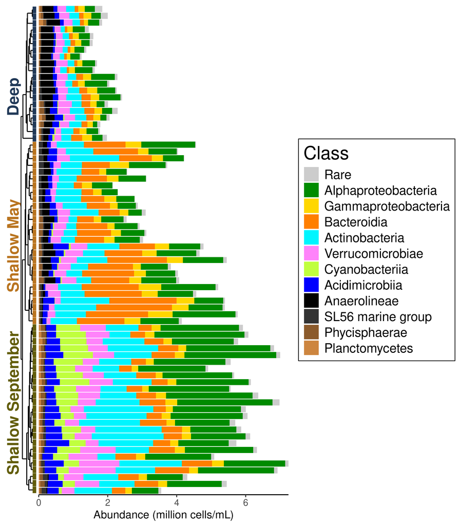

```r
class_df_abs <-
  full_abs_physeq %>%
  speedyseq::relocate_tax_table(ASV, .after = last_col()) %>%
  speedyseq::tax_glom(taxrank = "Class") %>%      # Agglomerate/merge counts by class using faster function
  psmelt() %>%                                         # melt into long format data frame
  mutate(Class = case_when(is.na(Class)~"Other",
                            TRUE ~ Class)) # Deal with NAs

# Here, I find which taxa are abundant enough that we can see them in the plot, and so are worth assigning colors
abund_taxa_abs <- class_df_abs %>%
  group_by(Class) %>%
  mutate(rare_c = max(Abundance) < 100000) %>%
  filter(!rare_c) %>%
  pull(Class) %>% unique()

# This is the order of samples in our dendrogram
rep_order <- dend_data$labels$label

class_barplot_abs <- class_df_abs %>%
  select(Class, Abundance, Comp_Group_Hier, Rep_ID) %>%
  mutate(Class = ifelse(Class %in% abund_taxa_abs, Class, "Rare"),
          Class = factor(Class, levels = names(class_colors))) %>%  # Mark rare taxa
  group_by(Class, Rep_ID, Comp_Group_Hier) %>%
  summarize(Abundance = sum(Abundance)) %>%
  ungroup() %>%
  mutate(Rep_ID = factor(Rep_ID, levels = rep_order)) %>%
  ggplot(aes(y = Rep_ID, x = Abundance/1e6, fill = Class)) +
  geom_bar(stat="identity") +
  scale_fill_manual(values = class_colors) +
  scale_x_continuous(expand = expansion(mult = 0),
                     labels = scales::label_comma()) +
  labs(x = "Abundance (million cells/mL)") +
  theme(axis.line.y = element_blank(),
        axis.text.y = element_blank(),
        axis.ticks.y = element_blank(),
        axis.title.y = element_blank(),
        plot.margin = unit(c(0,0,0,0), "null"),
        axis.text.x = element_text(size = 10),
        axis.title.x = element_text(size = 12),
        legend.text = element_text(size = 14),
        legend.title = element_text(size = 20)) +
  guides(fill = guide_legend(ncol = 1))

# This is the set of labels (Deep, Shallow May, Shallow September) which floats alongside
labels <- ggplot(data = data.frame(),
       aes(y = c(0, 37, 72),
           x = 0,
           label = c("Shallow September","Shallow May", "Deep"))) +
  geom_text(color = comp_three_colors[c(2,1,3)],
            angle = 90,
            size = 6,
            fontface = "bold") +
  theme_void() +
  scale_y_continuous(expand = expansion(mult = .3))


# This puts together our labels, our dendrogram, and our barplot
class_abs_abund <- labels + dendro_plot_for_barplots + class_barplot_abs +
  plot_layout(widths = c(.5,.5,8), ncol = 3)


class_abs_abund
```

# Absolute Most abundant ASVs

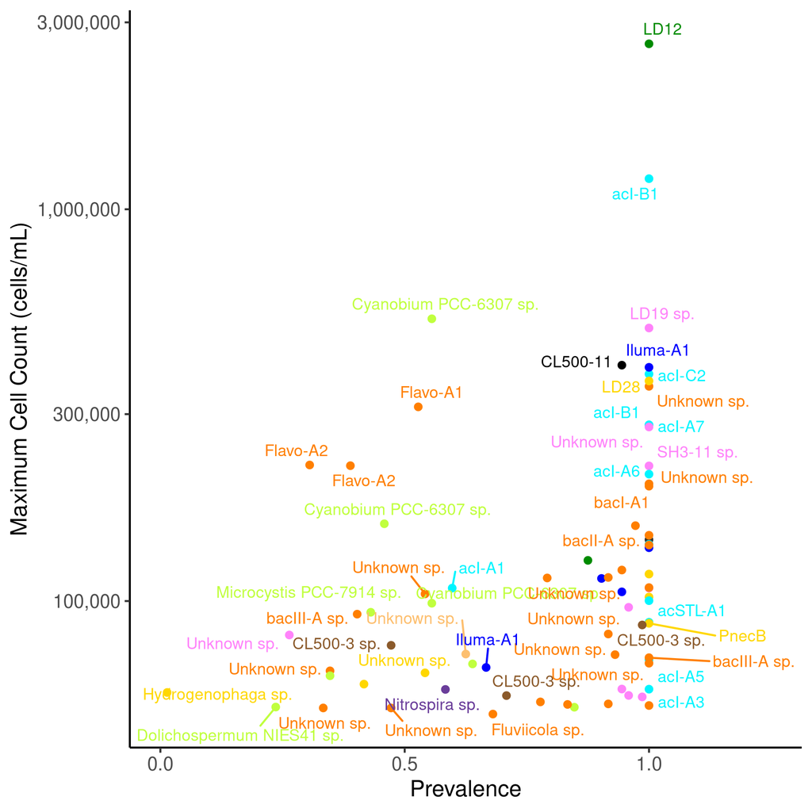

```r
# Make a dataframe with every ASV's abundance
asv_melted <- full_abs_physeq %>%
  psmelt()


annotations <- asv_melted %>%
  mutate(Species = case_when(!is.na(Species)~Species,
                             is.na(Species)&(!is.na(Genus))~paste(Genus, "sp."),
                             TRUE~paste("Unknown sp."))) %>% # Rename NAs
  select(ASV, Phylum, Class,Species) %>%
  unique() %>% # Collapse multiple zeros
  mutate(Species = case_when(ASV == "ASV_3"~"CL500-11", # We blasted this ASV and it matched CL500-11 the best
                             TRUE ~ Species))

asv_melted %>%
  select(ASV, Rep_ID, Abundance) %>%
  group_by(ASV) %>%
  summarize(Prevalence = sum(as.numeric(Abundance > 0)) / n(),
            Max_Abundance = max(Abundance)
            ) %>%
  left_join(annotations) %>%
  filter(Max_Abundance > 5e4) %>% # Zoom into the most abundance ASVs
  ggplot(aes(x = Prevalence, y = Max_Abundance, color = Class)) +
  geom_point() +
  geom_text_repel(aes(label = Species), size = 3)  +
  scale_y_continuous(transform = "log10", labels = scales::label_comma())+
  scale_x_continuous(limits = c(0, 1.25),
                     breaks = c(0,0.5, 1)) +
  scale_color_manual(values = class_colors) +
  labs(y = "Maximum Cell Count (cells/mL)", y = "Prevalence") +
  theme(legend.position = "none")
```

Here I do the same thing as above, but without an abundance cutoff. This means that we can’t really see specific species anymore, but can evalute the overall distributions of ASVs (and support our claim that we didn’t observe very many conditionally rare taxa).

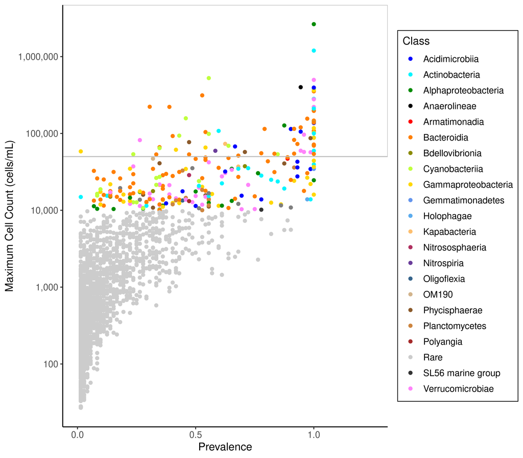

```r
all_asvs <- asv_melted %>%
  select(ASV, Rep_ID, Abundance) %>%
  group_by(ASV) %>%
  summarize(Prevalence = sum(as.numeric(Abundance > 0)) / n(),
            Max_Abundance = max(Abundance)
            ) %>%
  left_join(annotations) %>%
  mutate(Class = ifelse(Max_Abundance > 10000, Class, "Rare"),
         Class = ifelse(is.na(Class), "Unidentified",Class)) %>%
  ggplot(aes(x = Prevalence, y = Max_Abundance, color = Class)) +
  geom_point() +
  scale_y_continuous(transform = "log10", labels = scales::label_comma())+
  scale_x_continuous(limits = c(0, 1.25),
                     breaks = c(0,0.5, 1)) +
  scale_color_manual(values = class_colors) +
  labs(y = "Maximum Cell Count (cells/mL)", y = "Prevalence") +
  guides(color = guide_legend(
    title = "Class",
    ncol = 1,
    override.aes = aes(label = "")
  )) +
  annotate(geom = "rect", xmin = -Inf, xmax = Inf, ymin = 5e4, ymax = Inf,
           fill = NA, color = "grey")

all_asvs
```

# Highlighting Specific Taxa (Figures S6A and S15)

## Highlighting acI-C2 (Fig. S15)

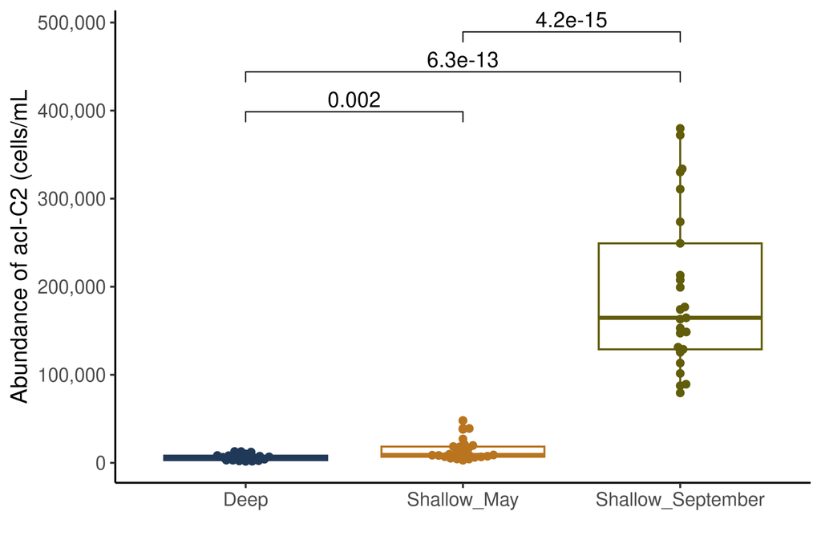

```r
asv_melted %>%
  filter(Species == "acI-C2") %>%
  ggplot(aes(x = Comp_Group_Hier, y = Abundance, color = Comp_Group_Hier)) +
  geom_boxplot() +
  ggbeeswarm::geom_beeswarm() +
  scale_y_continuous(labels = scales::label_comma()) +
  scale_color_manual(values = comp_three_colors) +
  ggpubr::stat_compare_means(comparisons = list(c(1,2), c(1,3), c(2,3))) +
  labs(x = "", y = "Abundance of acI-C2 (cells/mL") +
  theme(legend.position = "none")
```

Now I remake the figure, without the actual stats values, which I report in the text.

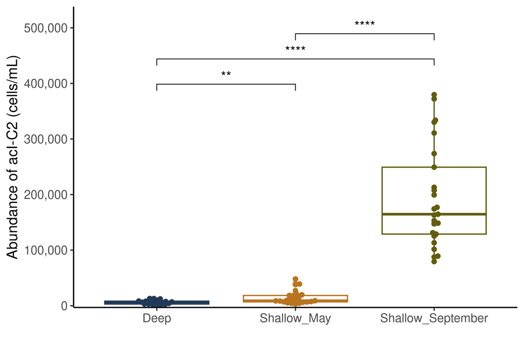

```r
asv_melted %>%
  filter(Species == "acI-C2") %>%
  ggplot(aes(x = Comp_Group_Hier, y = Abundance, color = Comp_Group_Hier)) +
  geom_boxplot() +
  ggbeeswarm::geom_beeswarm() +
  scale_y_continuous(labels = scales::label_comma(),
                     expand = expansion(c(0.01,0.1))) +
  scale_color_manual(values = comp_three_colors) +
  ggpubr::stat_compare_means(comparisons = list(c(1,2), c(1,3), c(2,3)),
                             label = "p.signif") +
  labs(x = "", y = "Abundance of acI-C2 (cells/mL)") +
  theme(legend.position = "none")
```

## Highlighting Deep Taxa in Upwelling (Fig. S6A)

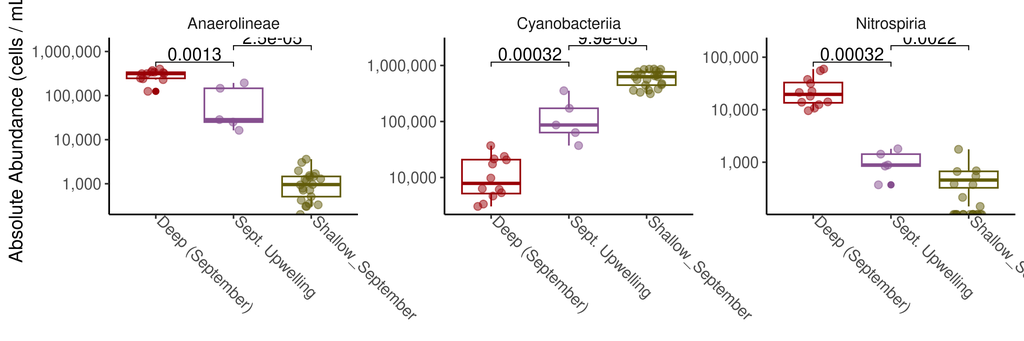

```r
asv_melted %>%
  filter(Comp_Group_Hier_Colors %in% c("Deep (September)", "Shallow_September")) %>%
  mutate(Comp_Group_Hier_Colors = ifelse(Rep_ID%in%c("September_38_E","September_35_E", "September_38_B", "September_35_M","September_35_B"), "Sept. Upwelling", Comp_Group_Hier_Colors)) %>%
  filter(Class %in% c("Nitrospiria","Anaerolineae", "Cyanobacteriia")) %>%
  group_by(Class, Rep_ID, Comp_Group_Hier_Colors) %>%
  summarize(Sum_Abund = sum(Abundance)) %>%
  ungroup() %>%
  ggplot(aes(x = Comp_Group_Hier_Colors, y = Sum_Abund, color = Comp_Group_Hier_Colors)) +
  geom_boxplot() +
  geom_jitter(size = 2, alpha = .5, width = 0.2) +
  facet_wrap(~Class, scales = "free_y", ncol = 3) +
  scale_y_log10(labels = scales::label_comma()) +
  scale_color_manual(values = c("#990006","#864F8F", "#625D0A")) +
  labs(y = "Absolute Abundance (cells / mL)") +
  theme(legend.position = "none",
        axis.text.x = element_text(angle = -45, hjust= 0, vjust = 0),
        axis.title.x = element_blank()) +
  ggpubr::stat_compare_means(comparisons = list(c(1,2),c(2,3)))
```

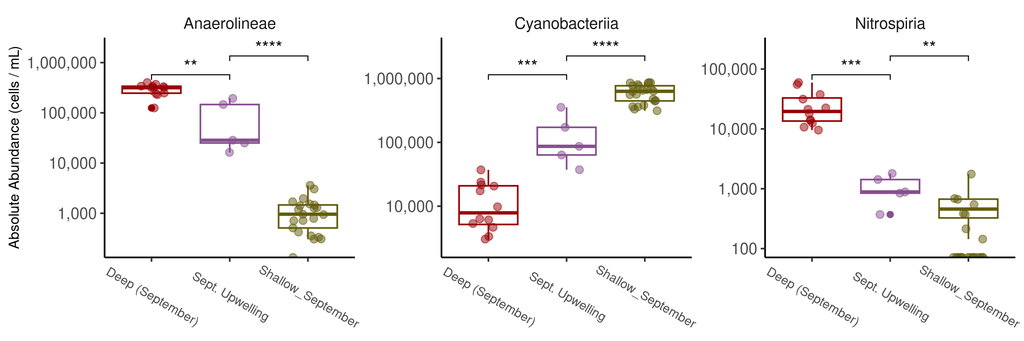

```r
asv_melted %>%
  filter(Comp_Group_Hier_Colors %in% c("Deep (September)", "Shallow_September")) %>%
  mutate(Comp_Group_Hier_Colors = ifelse(Rep_ID%in%c("September_38_E","September_35_E", "September_38_B", "September_35_M","September_35_B"), "Sept. Upwelling", Comp_Group_Hier_Colors)) %>%
  filter(Class %in% c("Nitrospiria","Anaerolineae", "Cyanobacteriia")) %>%
  group_by(Class, Rep_ID, Comp_Group_Hier_Colors) %>%
  summarize(Sum_Abund = sum(Abundance)) %>%
  ungroup() %>%
  ggplot(aes(x = Comp_Group_Hier_Colors, y = Sum_Abund, color = Comp_Group_Hier_Colors)) +
  geom_boxplot() +
  geom_jitter(size = 2, alpha = .5, width = 0.2) +
  facet_wrap(~Class, scales = "free_y", ncol = 3) +
  scale_y_log10(labels = scales::label_comma(),
                expand = expansion(0.1)) +
  scale_color_manual(values = c("#990006","#864F8F", "#625D0A")) +
  labs(y = "Absolute Abundance (cells / mL)") +
  theme(legend.position = "none",
        axis.text.x = element_text(angle = -30, hjust= .5, vjust = .2, size = 8),
        axis.title.x = element_blank(),
        axis.title.y = element_text(size = 9),
        strip.text = element_text(size = 10)) +
  ggpubr::stat_compare_means(comparisons = list(c(1,2),c(2,3)), label = "p.signif")
```

# Exploring Unique Taxa and Unique Interactions

First, we look at the ASV abundance distributions at different stations (near, or apart, from upwellings or the Welland Canal)

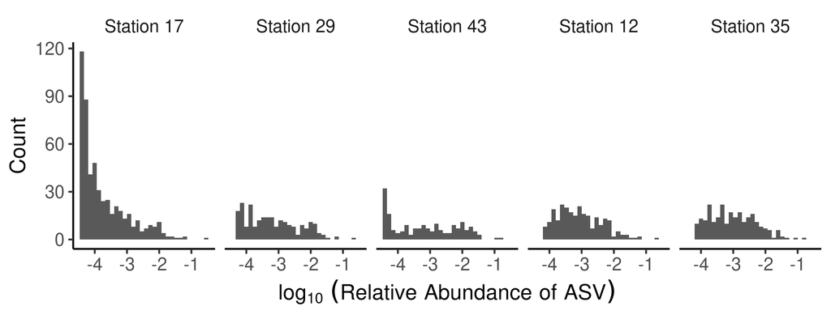

```r
asv_df_rel <-
  full_abs_physeq %>%
  transform_sample_counts(function(x) {x/sum(x)}) %>% # Convert to relative abundances
  psmelt()

asv_df_rel %>%
  filter(Station_ID %in% c(12, 17, 35, 43, 29),
         month == "May",
         Depth_Class == "E") %>%
  mutate(Station_ID = paste("Station", Station_ID),
         Station_ID = factor(Station_ID, levels = c("Station 17", "Station 29", "Station 43", "Station 12", "Station 35"))) %>%
  ggplot(aes(x = log10(Abundance))) +
  geom_histogram() +
  facet_wrap(~Station_ID, nrow = 1) +
  labs(x = bquote(log[10]~(Relative~Abundance~of~ASV)), y = "Count")
```

Repeat for September

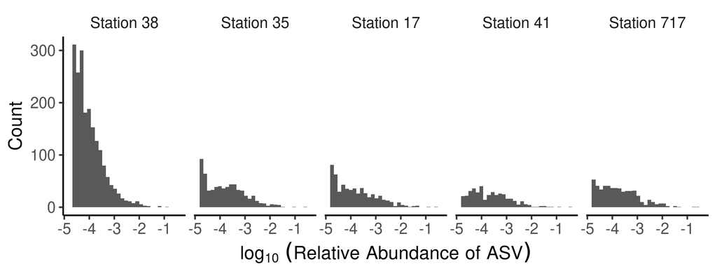

```r
asv_df_rel %>%
  filter(Station_ID %in% c(35, 38, 717, 41, 17),
         month == "September",
         Depth_Class == "E") %>%
  mutate(Station_ID = paste("Station", Station_ID),
         Station_ID = factor(Station_ID, levels = c("Station 38", "Station 35", "Station 17", "Station 41", "Station 717"))) %>%
  ggplot(aes(x = log10(Abundance))) +
  geom_histogram() +
  facet_wrap(~Station_ID, nrow = 1) +
  labs(x = bquote(log[10]~(Relative~Abundance~of~ASV)), y = "Count")
```

Now, I plot the taxonomic composition of the samples I showed above, but only of ASVs which had a relative abundance *less than 0.0001*! There’s a lot of code to tweak the ordering and aesthetics.

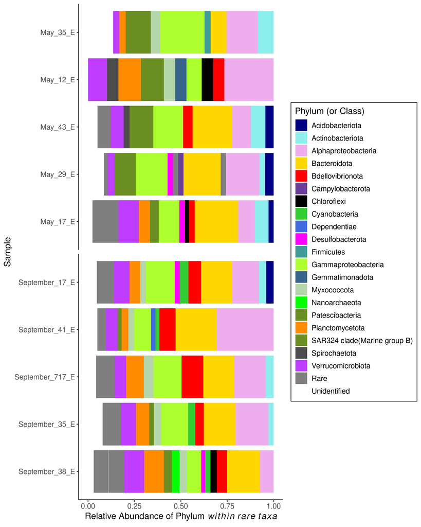

```r
rare_physeq <-
  full_abs_physeq %>%
  transform_sample_counts(function(x) {x/sum(x)}) %>%
  psmelt() %>%
  filter(Abundance < 0.0001) %>%
  group_by(ASV) %>%
  filter(sum(Abundance) > 0) %>%
  ungroup()

rare_rel_abund <- rare_physeq %>%
  select(Station_ID, Rep_ID, month, Abundance, Depth_Class, Phylum:Species) %>%
  filter(Abundance > 0) %>%
  group_by(Rep_ID) %>%
  mutate(Rel_Rare_Abund = Abundance / sum(Abundance)) %>%
  ungroup()

rare_rel_abund %>%
  filter(Depth_Class == "E",
         month == "September" & Station_ID %in% c(35, 38, 717, 41, 17)|month == "May" & Station_ID %in% c(17, 35, 12, 29, 43)) %>%
  mutate(Phylum = ifelse(Phylum == "Proteobacteria",Class, Phylum)) %>%
  group_by(Phylum, Rep_ID, month) %>%
  summarize(Phyl_Abund = sum(Rel_Rare_Abund)) %>%
  mutate(Phylum = case_when(is.na(Phylum) ~"Unidentified",
                            Phyl_Abund < 0.02~"Rare",
                            TRUE ~ Phylum),
         Phylum = factor(Phylum),
         Phylum = fct_relevel(Phylum, "Rare", after = Inf),
         Phylum = fct_relevel(Phylum, "Unidentified", after = Inf),
         Rep_ID = factor(Rep_ID, levels = c("May_17_E",
                                            "May_29_E",
                                            "May_43_E",
                                            "May_12_E",
                                            "May_35_E",
                                            "September_38_E",
                                            "September_35_E",
                                            "September_717_E",
                                            "September_41_E",
                                            "September_17_E"))

)  %>%
  ggplot(aes(y = Rep_ID, x = Phyl_Abund, fill = Phylum)) +
  geom_col() +
  scale_fill_manual(values = rare_phylum_colors) +
  facet_wrap(~month, nrow = 2, scales = "free_y") +
  labs(x = expression("Relative Abundance of Phylum"~italic(within~rare~taxa)),
       y = "Sample",
       fill = "Phylum (or Class)") +
  theme(strip.text = element_blank()) +
  guides(fill = guide_legend(ncol = 1))
```

# Identifying ASVs Unique to Upwelling Stations

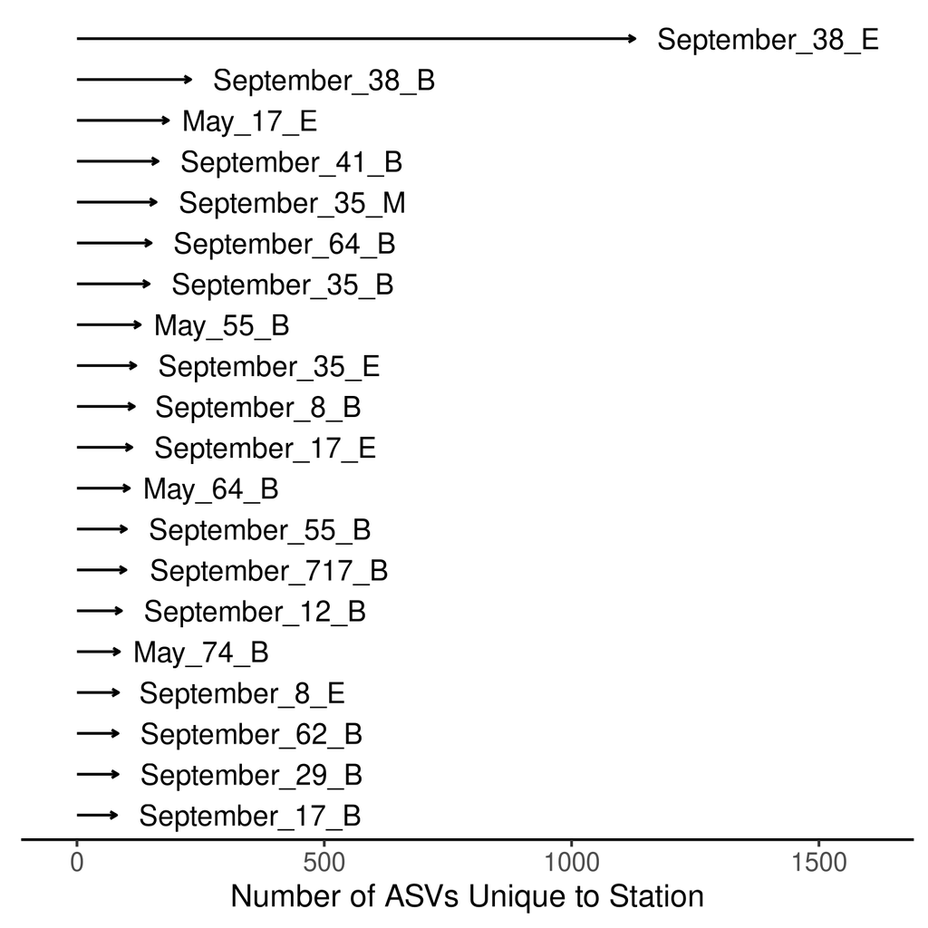

```r
# The trans stands for "transient"
trans_taxa <- asv_melted %>%
  filter(Abundance > 0) %>%
  count(OTU) %>%
  filter(n <= 1) %>%  # Find ASVs which are only observed in one sample
  pull(OTU)

asv_melted %>%
  filter(Abundance > 0) %>%
  filter(OTU %in% trans_taxa) %>%
  count(Rep_ID) %>%
  arrange(desc(n)) %>%
  slice_head(n = 20) %>% # Only choose the top 20 samples with the most "unique" taxa
  mutate(Rep_ID = factor(Rep_ID),
         Rep_ID = fct_reorder(Rep_ID, n)) %>%
  ggplot(aes(x = n, y = Rep_ID, label = Rep_ID, xend = 0)) +
  geom_segment(arrow = arrow(ends = "first", length = unit(0.1, "cm"))) +
  geom_text(hjust = -0.1) +
  scale_x_continuous(expand = expansion(c(0.1,0.5))) +
  labs(x = "Number of ASVs Unique to Station") +
  theme(axis.title.y = element_blank(),
        axis.text.y = element_blank(),
        axis.line.y = element_blank(),
        axis.ticks.y = element_blank())
```

Next, we look for unique interactions (pairs of ASVs only seen in one sample)

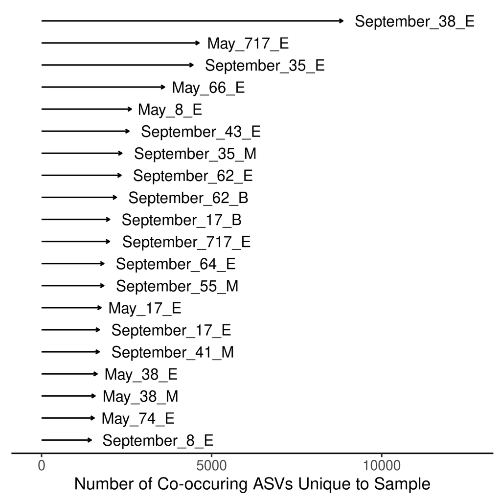

```r
pairs <- asv_melted %>%
  filter(Abundance > 1e3) %>% # Set a minimum abundance threshold
  select(Rep_ID, ASV) %>%
  group_by(Rep_ID) %>%
  reframe(A1 = t(combn(ASV, 2))) %>% # Make a row for EVERY combination of ASV in each Rep_ID
  rowwise() %>%
  mutate(pair_key = paste(sort(A1), collapse = ":")) %>% # Make a pair_key, which is each ASV name pasted together, but in alphabetical order (to prevent duplicates)
  ungroup()

trans_interactions <- pairs %>%
  count(pair_key) %>%
  filter(n == 1) %>% # Find interactions that only occur in one sample
  pull(pair_key)

pairs %>%
  filter(pair_key %in% trans_interactions) %>%
  count(Rep_ID) %>%
  arrange(desc(n)) %>%
  slice_head(n = 20) %>% # Same as above - select 20 samples with most unique interactions
  mutate(Rep_ID = factor(Rep_ID),
         Rep_ID = fct_reorder(Rep_ID, n)) %>%
  ggplot(aes(x = n, y = Rep_ID, label = Rep_ID, xend = 0)) +
  geom_segment(arrow = arrow(ends = "first", length = unit(0.1, "cm"))) +
  geom_text(hjust = -0.1) +
  scale_x_continuous(expand = expansion(c(0.1,0.5))) +
  labs(x = "Number of Co-occuring ASVs Unique to Sample") +
  theme(axis.title.y = element_blank(),
        axis.text.y = element_blank(),
        axis.line.y = element_blank(),
        axis.ticks.y = element_blank())
```

# Saving out relevant objects for spatial analysis

```r
save(full_abs_physeq, file = "data/08_compositional_exports/full_abs_physeq.RData")
```